# RLab5 report

Ryan Peters

# Exercises

```r
# pkgload is a custom script that's defined inside of the shared_lab_utils folder
pkgload(c("devtools","crayon","utils"))
# Instead of forcing the script to reload the dataframe every time we run it,
# lets do a quick check to see if it's already been instantiated from a
# previsou run first
df_name <- 'ames'
if (exists(df_name)) is.data.frame(get(df_name)) else{
  download.file('http://www.openintro.org/stat/data/ames.RData', destfile = 'ames.RData')
  load('ames.RData')
}
```

```r
area <- ames$Gr.Liv.Area
price <- ames$SalePrice
# getmode(vector) is a custom function defined in prep_script
area_mode <- area[which.max(tabulate(match(unique(area),area)))]
price_mode <- price[which.max(tabulate(match(unique(price),price)))]
```

```r
sumry <- summary(area)
sumry["mode"] <- area_mode
for(name in names(sumry)){
  cat("\n",name,":",sumry[name],"\n")
}
```

Min. : 334

1st Qu. : 1126

Median : 1442

Mean : 1499.69

3rd Qu. : 1742.75

Max. : 5642

mode : 1656

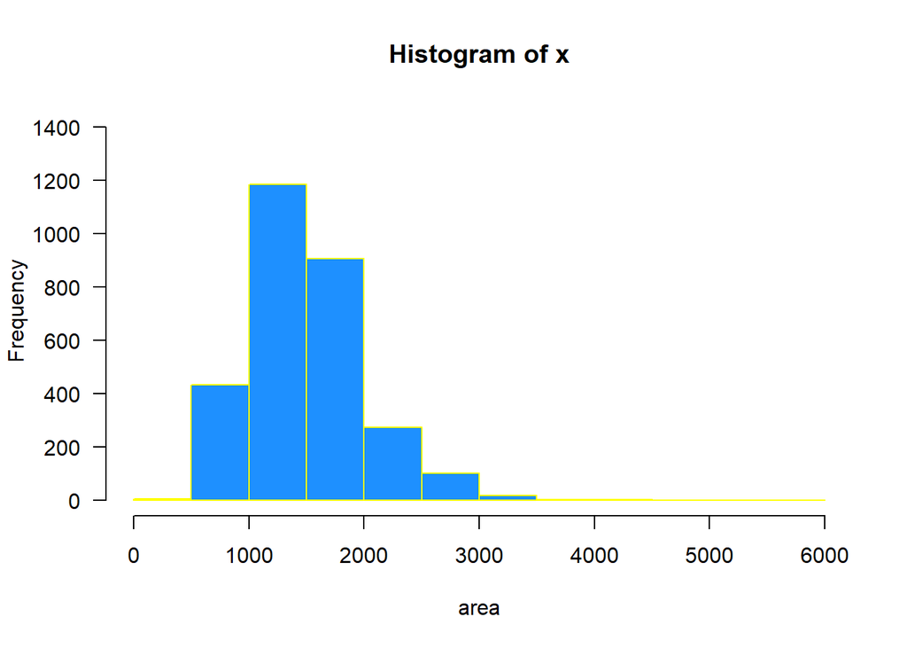

```r
hist_with_labels(area, border="yellow", col="dodgerblue", las=1, xlab="area")
```

### Exercise 1:

**Describe this population distribution.**

This is a right-skewed (aka right-tailed) distribution, with a mean of 1500 ft<sup>2</sup> and a median of 1442 ft<sup>2</sup>.

Jump to Table of Contents

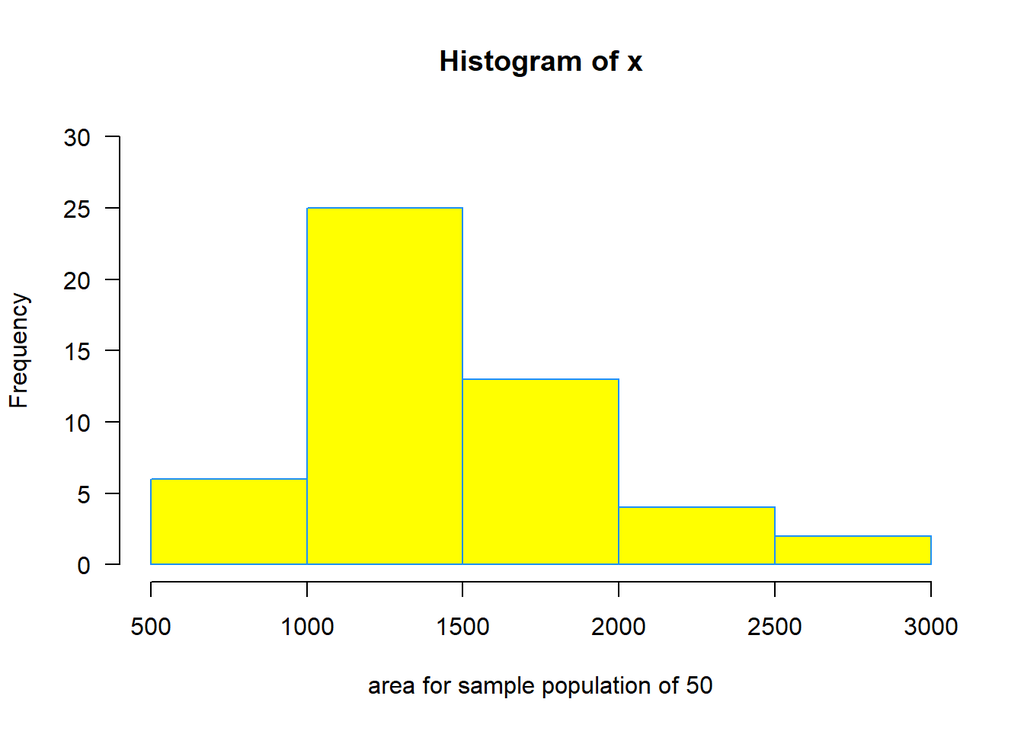

```r
samp1 <- sample(area, 50)
hist_with_labels(samp1, border="dodgerblue", col="yellow", las=1, xlab="area for sample population of 50")
```

### Exercise 2:

**Describe the distribution of this sample. How does it compare to the distribution of the population?**

It still appears to be right skewed, but it is definitly closer to a normal distribution than the total population

Jump to Table of Contents

```r
mean(samp1)
```

[1] 1454.98

```r
samp2 <- sample(area, 50)
mean(samp2)
```

[1] 1471.58

### Exercise 3:

**Take a second sample, also of size 50, and call it samp2.**

**How does the mean of samp2 compare with the mean of samp1?**

It is definetly different, but it’s hard to say if that’s purely due to chance or the distribution of the population.

**Suppose we took two more samples, one of size 100 and one of size 1000. Which would you think would provide a more accurate estimate of the population mean?**

I believe that as the sample size gets larger, the accuracy of its sample statistics in approximating the population parameters directly improves. So I believe the 1000 sample would be better at approximating the total population’s mean.

Jump to Table of Contents

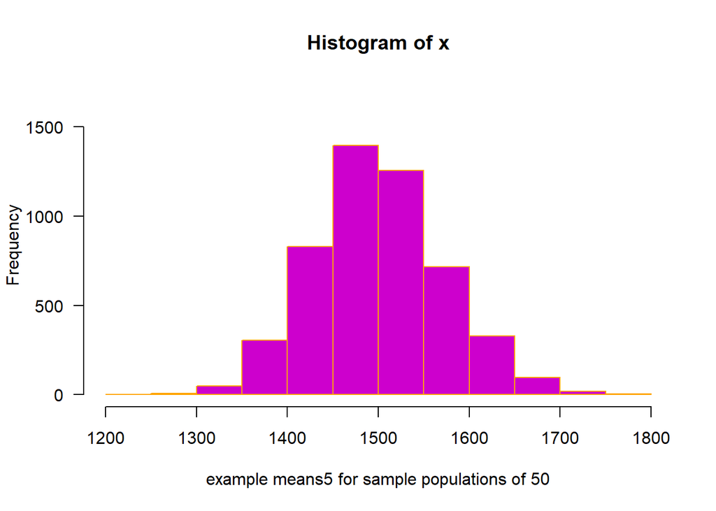

```r
sample_means50 <- rep(NA, 5000)

for(i in 1:5000){
  samp <- sample(area, 50)
  sample_means50[i] <- mean(samp)
}

hist_with_labels(sample_means50, text_col = "black", border="orange", col="magenta3", las=1, xlab="example means5 for sample populations of 50")
```

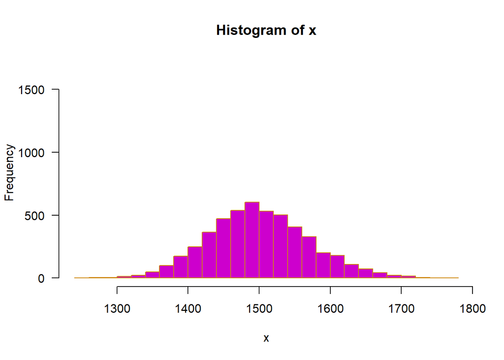

```r
hist_with_labels(sample_means50, text_col = "black", border="orange3", col="magenta3", las=1,breaks = 25)
```

### Exercise 4:

**How many elements are there in sample_means50?**

```r
length(sample_means50)
```

[1] 5000

**Describe the sampling distribution, and be sure to specifically note its center.**

It’s an approximately normal distribution, with a mean around 1500.

**Would you expect the distribution to change if we instead collected 50,000 sample means?**

I would expect the distribution to continue to further conform to that of a normal distribution.

Jump to Table of Contents

```r
sample_means50 <- rep(NA, 5000)

samp <- sample(area, 50)
sample_means50[1] <- mean(samp)

samp <- sample(area, 50)
sample_means50[2] <- mean(samp)

samp <- sample(area, 50)
sample_means50[3] <- mean(samp)

samp <- sample(area, 50)
sample_means50[4] <- mean(samp)
```

```r
sample_means50 <- rep(NA, 5000)

for(i in 1:5000){
  samp <- sample(area, 50)
  sample_means50[i] <- mean(samp)
  # print(i)
}
```

### Exercise 5:

**To make sure you understand what you’ve done in this loop, try running a smaller version. Initialize a vector of 100 zeros called sample_means_small. Run a loop that takes a sample of size 50 from area and stores the sample mean in sample_means_small, but only iterate from 1 to 100. Print the output to your screen (type sample_means_small into the console and press enter). How many elements are there in this object called sample_means_small? What does each element represent?**

Nope, no answers here…

Jump to Table of Contents

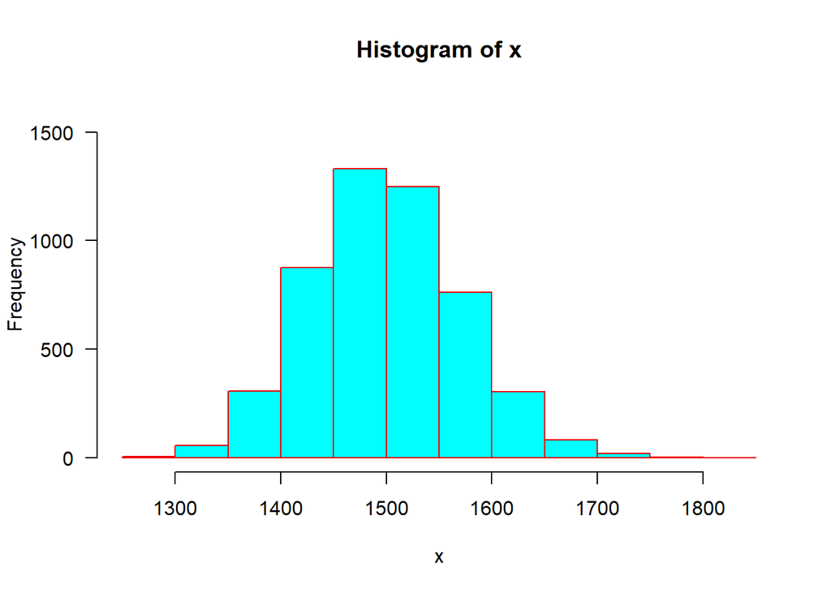

```r
hist_with_labels(sample_means50, text_col = "black", border="red2", col="cyan", las=1)
```

```r
sample_means10 <- rep(NA, 5000)
sample_means100 <- rep(NA, 5000)

for(i in 1:5000){
  samp <- sample(area, 10)
  sample_means10[i] <- mean(samp)
  samp <- sample(area, 100)
  sample_means100[i] <- mean(samp)
}
```

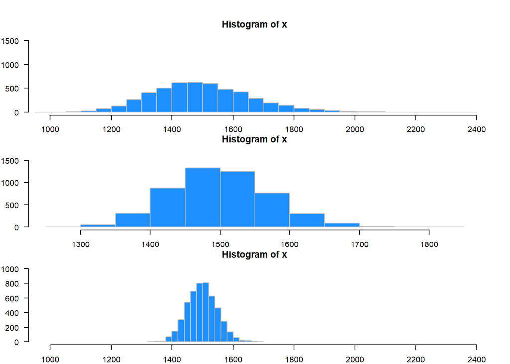

```r
par(mfrow = c(3, 1),
    oma = c(0,0,0,0) + 1,
    mar = c(0,1,2,1) + 1)

xlimits <- range(sample_means10)

# hist(sample_means10, breaks = 20, xlim = xlimits)
hist_with_labels(sample_means10, text_col = "yellow", breaks = 20, xlim = xlimits, border="gray", col="dodgerblue", las=1)
# hist(sample_means50, breaks = 20, xlim = xlimits)
hist_with_labels(sample_means50, text_col = "yellow", border="gray", col="dodgerblue", las=1)
# hist(sample_means100, breaks = 20, xlim = xlimits)
hist_with_labels(sample_means100, text_col = "yellow", breaks = 20, xlim = xlimits, border="gray", col="dodgerblue", las=1)
```

### Exercise 6:

**When the sample size is larger, what happens to the center? What about the spread?**

Jump to Table of Contents

=====

# On your own

So far, we have only focused on estimating the mean living area in homes in Ames. Now you’ll try to estimate the mean home price.

### On Your Own 1:

**Take a random sample of size 50 from price. Using this sample, what is your best point estimate of the population mean?**

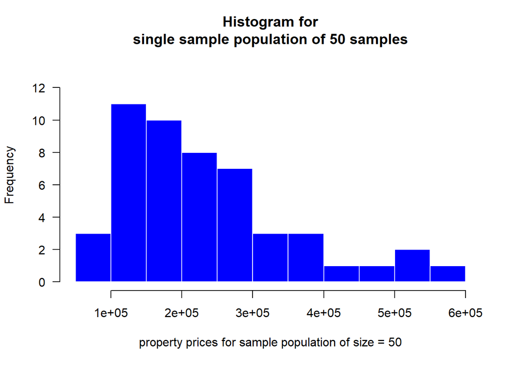

```r
price_sample <- sample(price, 50)
hist_with_labels(price_sample,
                 border="white",
                 col="blue1",
                 las=1,
                 xlab="property prices for sample population of size = 50",
                 main="Histogram for\nsingle sample population of 50 samples")
```

```r
smry <- summary(price_sample)
cat("My best point estimate for the population mean is the sample mean: ***",smry[[4]],"***\n",sep="")
```

My best point estimate for the population mean is the sample mean: *233291.7*

Jump to Table of Contents

### On Your Own 2:

**Since you have access to the population, simulate the sampling distribution for x-bar for price data by taking 5000 samples from the population of size 50 and computing 5000 sample means. Store these means in a vector called sample_means50.**

```r
sample_means50 <- range(5000)
for(i in 0:5000){
   sample_means50[i] <- mean(sample(price,50))
}
```

**Plot the data, then describe the shape of this sampling distribution.**

[figure not shown]

```r
hist_with_labels( sample_means50,
                  border="white",
                  col="blue1",
                  las=1,
                  xlab= "property value averages from sample populations of size = 50",
                  main="Histogram of means for\n50k sample populations of 50 samples a pieace")
```

```r
smry_50k <- summary( sample_means50)
```

**Based on this sampling distribution, what would you guess the mean home price of the population to be?**

The distribution is approximately normal, maybe slightly skewed to the rigt still From the histogram, I would estimate the mean home price to be approximately $180k

**Finally, calculate and report the population mean.**

```r
cat("The calculated mean of 50k means on sample populations of 50... is: ***",smry_50k[[4]],"***\n",sep="")
```

[output not shown]

Jump to Table of Contents

### On Your Own 3:

**Change your sample size from 50 to 150, then compute the sampling distribution using the same method as above, and store these means in a new vector called sample_means150.**

**Describe the shape of this sampling distribution, and compare it to the sampling distribution for a sample size of 50.**

**Based on this sampling distribution, what would you guess to be the meansale price of homes in Ames?**

[figure not shown]

```r
sample_means150 <- range(5000)
for(i in 0:5000){
   sample_means150[i] <- mean(sample(price,150))
}

hist_with_labels( sample_means150,
                  border="white",
                  col="blue1",
                  las=1,
                  xlab= "property value averages from sample populations of size = 150",
                  main="Histogram of means for\n50k sample populations of 150 samples a pieace")
```

```r
smry_150k <- summary( sample_means150)

cat("The distribution is approximately normal, though it is much less skewed than the sample size of only 50\nFrom the histogram, I would estimate the mean home price to be approximately $182k\nThe calculated mean of 50k means  on sample populations of 150... is: ***",smry_150k[[4]],"***\n",sep="")
```

[output not shown]

Jump to Table of Contents

### On Your Own 4:

**Of the sampling distributions from 2 and 3, which has a smaller spread?**

```r
cat("The larger sample population has the smaller spread")
```

The larger sample population has the smaller spread **If we’re concerned with making estimates that are more often close to the true value, would we prefer a distribution with a large or small spread?**

```r
price_summary <- summary(price)
true_mean <- price_summary[[4]]
winner_winner_chicken_dinner = "Neither sample size has a clear advantage"
if(abs(smry_50k[[4]]-true_mean) < abs(smry_150k[[4]]-true_mean)){
  # the smaller sample size is closer to the true mean
  winner_winner_chicken_dinner = "The smaller sample size appears to yield results closer to the population parameter mean"
} else if(abs(smry_50k[[4]]-true_mean) < abs(smry_150k[[4]]-true_mean)){
  # the larger sample size is closer to the true mean
  winner_winner_chicken_dinner = "The larger sample size appears to yield results closer to the population parameter mean"
}
```

I believe we would want a distribution with a narrower spread as it will more consistently provide an approximation that is reliably close to the true mean.

Jump to Table of Contents

# Disclaimers and such

This is a product of OpenIntro that is released under a Creative Commons Attribution-ShareAlike 3.0 Unported.

This lab was written for OpenIntro by Andrew Bray and Mine Çetinkaya-Rundel.